# DAUR2_les5

Stephanie de Wit

5-4-2022

**Introductie** Geïnduceerde pluripotente stamcellen (iPSCs) zijn huidcellen die zijn gededifferentieerd tot stamcellen. Ze worden ingezet voor weefselherstel of het genereren van niet-isoleerbare weefsels. In deze iPSC studie zijn fibroblasten uit twee proefpersonen geïsoleerd. Uit deze fibroblasten zijn iPSCs gemaakt door de transcriptiefactoren MYC, OCT3/4, SOX2 en KLF4 tot overexpressie te laten komen. Men wilt onderzoeken welke genen betrokken zijn bij de dedifferentiatie oftewel welke genen anders tot expressie komen o.i.v. deze transcriptiefactoren.

Onderzoeksvraag: Wat zijn de verschillen in genexpressie tussen iPSCs en fibroblasten?

! Paired-end reads ! Stranded protocol (reads gebruiken om te bepalen of RNA moleculen van plus of min strand kwamen)

**Onderdeel 1b** SRA identifiers in textfile:

```bash
for $fastq in $(cat iPSC_SRA.txt)
do
fastq-dump --split-3 --outdir "/home/daur2/rnaseq/rnaseq_ipsc/fastq" --gzip $fastq
done
```

**Onderdeel 1c** De kwaliteit van de reads is goed: van elke read heeft het grootste deel van de bps een “groene” Phred score.

**Onderdeel 1d**

```r
FO_fastq_dir<-"/home/daur2/rnaseq/rnaseq_ipsc/fastq/" #Variable met fastq files locatie.
hg38_index<-"/home/daur2/rnaseq/hg38_index/hg38_index" #Variable met basename van index
FO_bam_dir<-"/home/daur2/rnaseq/rnaseq_ipsc/bam/" #Variable met output locatie voor BAM files.
FO_samples<-list.files(FO_fastq_dir,pattern="_[12].fastq.gz")%>%str_remove(pattern="_[12].fastq.gz")%>%unique() #Variable met unieke sample namen

alignment_statistics<-align(
  index=hg38_index,
  readfile1=paste0(FO_fastq_dir,FO_samples,"_1.fastq.gz"),
  readfile2=paste0(FO_fastq_dir,FO_samples,"_2.fastq.gz"),
  type="rna",
  input_format="gzFASTQ",
  output_format="BAM",
  unique=TRUE, #Unique=TRUE geeft alleen reads die op één plek in het genoom alignen. Reads die op meerdere plekken alignen zijn onbetrouwbaar terug te plaatsen.
  nthreads=10) #nthreads geeft aan hoeveel CPU de computer gaat gebruiken voor de alignment.

saveRDS(alignment_statistics,file=paste0(FO_bam_dir,"alignment_statistics.rds")) #Sla alignment op als R file
```

**Onderdeel 1e**

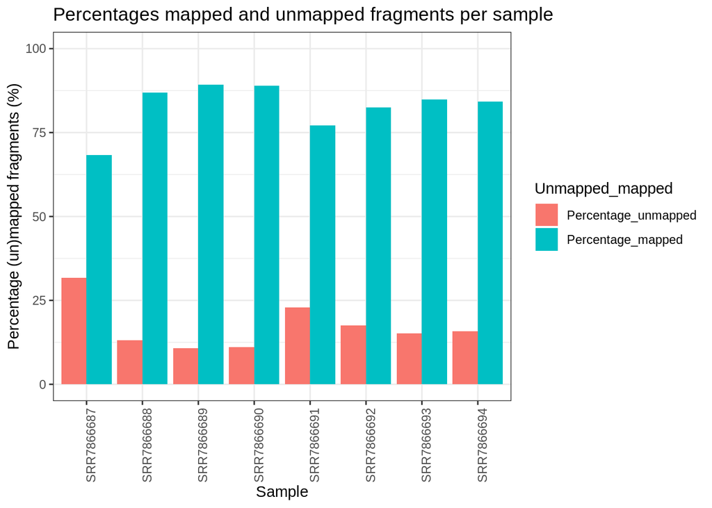

```r
FO_alignment_statistics<-readRDS("/home/daur2/rnaseq/rnaseq_ipsc/bam/alignment_statistics.rds")
FO_align_stats_plot<-as_tibble(t(FO_alignment_statistics)) #Tidy tibble maken
FO_align_stats_plot<-FO_align_stats_plot%>%mutate(Sample=c("SRR7866687","SRR7866688","SRR7866689","SRR7866690","SRR7866691","SRR7866692","SRR7866693","SRR7866694")) #Kolom toevoegen met sample namen (zijn verloren gegaan)
FO_align_stats_plot<-FO_align_stats_plot%>%mutate(Percentage_mapped=Mapped_fragments/Total_fragments*100) #Kolom toevoegen met percentage mapped fragments
FO_align_stats_plot<-FO_align_stats_plot%>%mutate(Percentage_unmapped=Unmapped_fragments/Total_fragments*100) #Kolom toevoegen met percentage unmapped fragments

FO_align_stats_plot<-FO_align_stats_plot%>%pivot_longer(cols=c("Percentage_mapped","Percentage_unmapped"),names_to="Unmapped_mapped",values_to="Percentage") #Maak een variabele van mapped-zijn of unmapped-zijn waarop gegroepeerd kan worden in de bar chart.
FO_align_stats_plot$Unmapped_mapped<-factor(FO_align_stats_plot$Unmapped_mapped,levels=c("Percentage_unmapped","Percentage_mapped")) #Levels-volgorde aanpassen zodat mapped = groen in bar chart

ggplot(FO_align_stats_plot,aes(x=Sample,y=Percentage,fill=Unmapped_mapped))+
  geom_col(position=position_dodge())+
  labs(title="Percentages mapped and unmapped fragments per sample",x="Sample",y="Percentage (un)mapped fragments (%)")+
  ylim(0,100)+
  theme_bw()+
  theme(axis.text.x=element_text(angle=90))
```

**Onderdeel 2a**

```r
FO_bam_dir<-"/home/daur2/rnaseq/rnaseq_ipsc/bam/" #Variable maken met locatie input BAM files
FO_counts_dir<-"/home/daur2/rnaseq/rnaseq_ipsc/counts/" #Variable maken met locatie output count table
FO_bam_files<-list.files(FO_bam_dir,pattern=".*\\.bam$",full.names=TRUE) #Character vector met BAM files namen

FO_read_counts<-featureCounts(
  files=FO_bam_files,
  annot.inbuilt="hg38", #Built-in
  useMetaFeatures=TRUE,
  strandSpecific=1, #Stranded protocol, dus 1 gebruiken?
  isPairedEnd=TRUE,
  countReadPairs=TRUE,
  nthreads=10
)
```

**Onderdeel 2b**

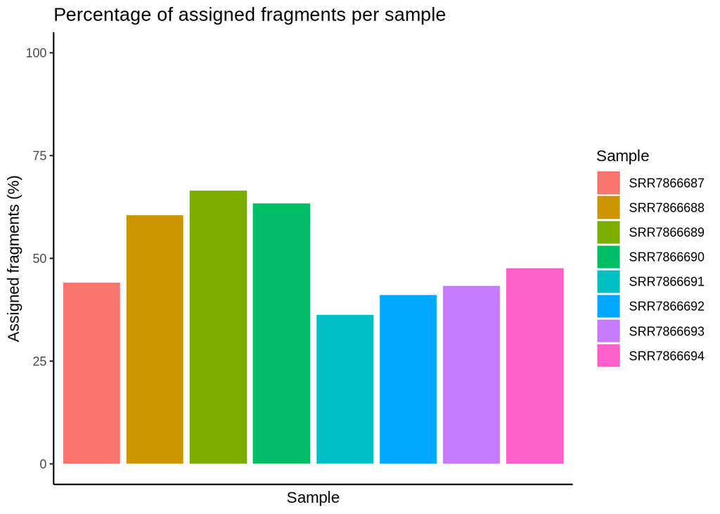

```r
FO_read_counts<-readRDS("/home/daur2/rnaseq/rnaseq_ipsc/counts/read_counts.rds")
FO_count_stats<-FO_read_counts$stat #$Stat extraheren uit count table
rownames(FO_count_stats)<-FO_count_stats$Status #Waarden onder $Status gebruiken als rij namen...
FO_count_stats$Status<-NULL #... en $Status verwijderen
FO_count_stats_plot<-as_tibble(t(FO_count_stats)) #Rijen en kolommen omdraaien. Bij omzetten naar tibble gaan rijnamen alsnog verloren, dus...
FO_count_stats_plot<-FO_count_stats_plot%>%mutate(Sample=names(FO_count_stats)) #... kolom namen originele count_stats gebruiken in nieuwe variabele
FO_count_stats_plot<-FO_count_stats_plot%>%mutate(Perc_Assigned=Assigned/colSums(FO_count_stats)*100) #Totale hvh voor elke rij = sample is gelijk aan de som van alle opties die in originele count_stats in één kolom = sample staan.
FO_count_stats_plot$Sample<-str_remove(FO_count_stats_plot$Sample,pattern=".bam") #Verwijder .bam uit de sample namen

ggplot(FO_count_stats_plot,aes(x=Sample,y=Perc_Assigned,fill=Sample))+
  geom_col()+
  labs(title="Percentage of assigned fragments per sample",x="Sample",y="Assigned fragments (%)")+
  ylim(0,100)+
  theme_classic()+
  theme(axis.ticks.x=element_blank(),axis.text.x=element_blank())
```

**Onderdeel 2c** Count table omzetten tot DESeq object voor normalisatie.

```r
FO_count_matrix<-FO_read_counts$counts
```

```r
FO_metadata<-read_csv("/home/daur2/rnaseq/rnaseq_ipsc/ipsc_sampledata.csv")
FO_metadata<-as.data.frame(FO_metadata)
rownames(FO_metadata)<-paste0(FO_metadata$Run,".bam") #Onder $Run staan SRA identifiers
colnames(FO_count_matrix)==rownames(FO_metadata)
```

```
## [1] TRUE TRUE TRUE TRUE TRUE TRUE TRUE TRUE
```

```r
FO_metadata$Cell_type<-FO_metadata$Cell_type%>%factor(levels=c("Skin derived fibroblast","iPSC")) #Zet de level volgorde met de "controle" als het 1e level; dit level wordt gebruikt als referentie.
```

```r
FO_dds<-DESeqDataSetFromMatrix(
  countData=FO_count_matrix,
  colData=FO_metadata,
  design=~Cell_type)
```

```
##   Note: levels of factors in the design contain characters other than
##   letters, numbers, '_' and '.'. It is recommended (but not required) to use
##   only letters, numbers, and delimiters '_' or '.', as these are safe characters
##   for column names in R. [This is a message, not a warning or an error]
```

**Onderdeel 2d**

```r
FO_dds_normalized<-rlog(FO_dds)
```

```
##   Note: levels of factors in the design contain characters other than
##   letters, numbers, '_' and '.'. It is recommended (but not required) to use
##   only letters, numbers, and delimiters '_' or '.', as these are safe characters
##   for column names in R. [This is a message, not a warning or an error]
```

```r
FO_pca<-FO_dds_normalized%>%assay()%>%t()%>%prcomp()
FO_pca_summary<-summary(FO_pca)$importance
```

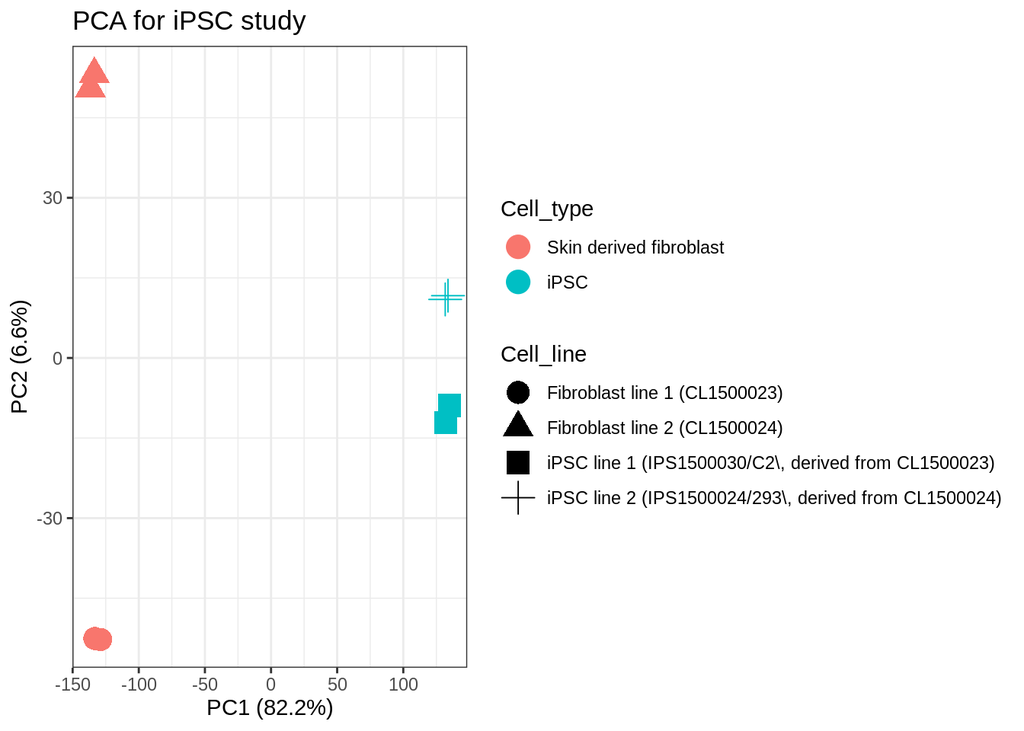

```r
FO_pca_plotting<-cbind(FO_metadata,FO_pca$x) #Maak een df met de metadata en PCA waarden: per SRA identifier het celtype, de conditie en PC1 t/m PC8

FO_PC1_var<-round(FO_pca_summary["Proportion of Variance","PC1"]*100,digits=1)
FO_PC2_var<-round(FO_pca_summary["Proportion of Variance","PC2"]*100,digits=1)
#Maak variabelen met de percentages gedekte variatie

ggplot(FO_pca_plotting,aes(x=PC1,y=PC2,colour=Cell_type,shape=Cell_line))+
  geom_point(size=5)+
  ggtitle("PCA for iPSC study")+
  xlab(paste0("PC1 (", FO_PC1_var, "%)"))+
  ylab(paste0("PC2 (", FO_PC2_var, "%)"))+
  theme_bw()
```

**Samples clusteren samen gebaseerd op op het celtype.**

**Onderdeel 2e**

```r
FO_dss_normalized_matrix<-assay(FO_dds_normalized) #Extraheer matrix uit genormaliseerd DESe object
iPSC_cor<-cor(FO_dss_normalized_matrix) #Verkrijg de correlatie coëfficiënten tussen de samples
```

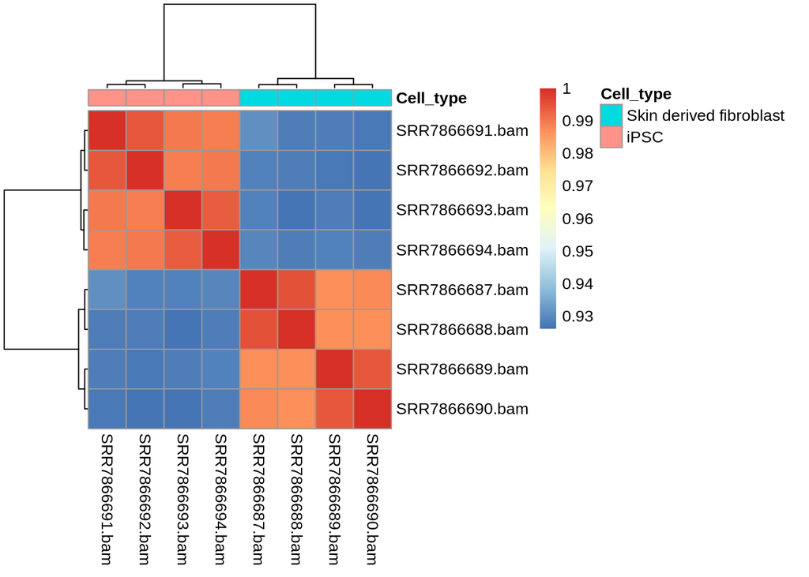

```r
pheatmap(iPSC_cor,annotation=FO_metadata[9]) #Annoteer o.b.v. het celtype.
```

**De clustering laat zien dat de vier fibroblast samples onderling veel sterker gecorreleerd zijn dan aan iPSCs en dat geldt ook voor de vier iPSC samples. De samples clusteren idd samen gebaseerd op celtype.**

**Onderdeel 3a**

```r
iPSC_dge<-DESeq(FO_dds)
```

```
##   Note: levels of factors in the design contain characters other than
##   letters, numbers, '_' and '.'. It is recommended (but not required) to use
##   only letters, numbers, and delimiters '_' or '.', as these are safe characters
##   for column names in R. [This is a message, not a warning or an error]
```

[output not shown]

[output not shown]

```r
iPSC_dge_results<-results(iPSC_dge,alpha=0.05,lfcThreshold=1) #Per gen de P-waarde en LFC voor fibroblast vs iPSC, met aangepaste alpha en LFC threshold
summary(iPSC_dge_results)
```

```
##
## out of 23095 with nonzero total read count
## adjusted p-value < 0.05
## LFC > 1.00 (up)    : 3222, 14%
## LFC < -1.00 (down) : 2510, 11%
## outliers [1]       : 3, 0.013%
## low counts [2]     : 4424, 19%
## (mean count < 1)
## [1] see 'cooksCutoff' argument of ?results
## [2] see 'independentFiltering' argument of ?results
```

**Er zijn 3222 genen upgereguleerd en 2510 genen downgereguleerd. Dat zijn er veel meer dan voor de airway studie bij een alpha van 0.05 en LCF threshold van 1.**